# Sea born assignment

```
import pandas as pd
import numpy as np
import matplotlib.pylab as plt
import seaborn as sns
import scipy
%matplotlib inline

df=pd.read_csv(r"C:\Users\0774051680\Downloads\Compressed\house-prices from kaggle\Housing prices.csv")
```

## Q2) 81 variables in this data. Select any 6 variables you feel important including {SalePrice} and create a Seaborn pairplot. Based on this plot interpret your initial idea about the data. (75 – 125 words)

```
imp_var=df[['SalePrice','YrSold','LotArea','SaleType','GrLivArea','GarageArea']]

sns.set_style(style="darkgrid")
sns.pairplot(imp_var,hue='SaleType', plot_kws = {'alpha': 0.6, 's': 80, 'edgecolor': 'k'},height = 4,diag_kind ='kde');
```

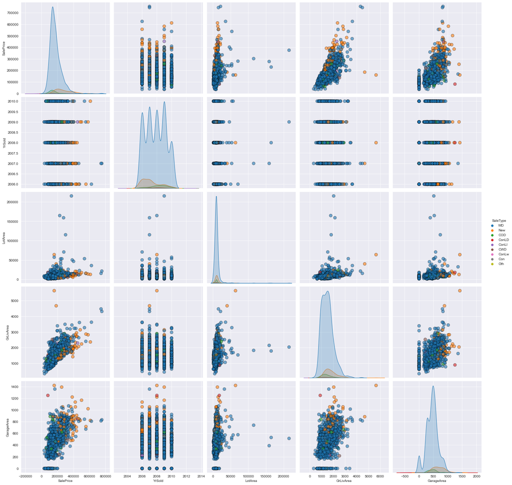

Here we can see most of the most of the sale type is Warranty Deed. here we can see 2 possitive linear correlation

- *1.sale price and GrLivArea*
- *2.sale price and GarageArea*

there is no correlation between Lot area and sale price

campare to the year, we can say from 400000 to 500000.there is no house in 2010.

## Q3) Price is the important variable and understanding the distribution of price is very important to understand the data. [15 marks >> 5 each]

### a) Create a simple chart to identify the overall distribution of price variable and interpret it. {SalePrice}

```
sns.set_style(style="darkgrid")
sns.displot(data=df,x='SalePrice',bins=10,kde=True,aspect=2,color="y");
```

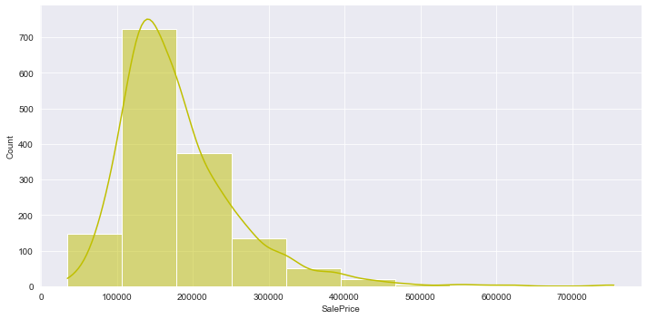

this histogram goes skewed to the right.we can see most of the ouse prices are between 100000 to 200000.maximum price of house goes up to 700000.this histogram has a peak point.

### b) Identify the distribution of price with respect to different Types of foundation inside a single chart figure {SalePrice, Foundation}

```
sns.set_style(style="darkgrid")
sns.displot(data=df,x='SalePrice',bins=10,hue='Foundation',kde=True,palette="Set1");
```

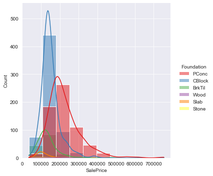

we have Cinder block Foundation houses more than 400 within 10,0000 and 200000.but Poured Contrete Foundation houses a less them 300 in this price range.

110000 price house is around 100 available in Brick & Tile foundation

### c) Create a chart or facet grid to identify the distribution of price with respect to alley access and condition of the material on the exterior. (Use kernel density estimation plots for smooth charts) {SalePrice, Alley, ExterCond}

```
sns.set_style(style="darkgrid")
g=sns.FacetGrid(data=df,col='ExterCond',row='Alley')
g=g.map(sns.kdeplot,'SalePrice');
```

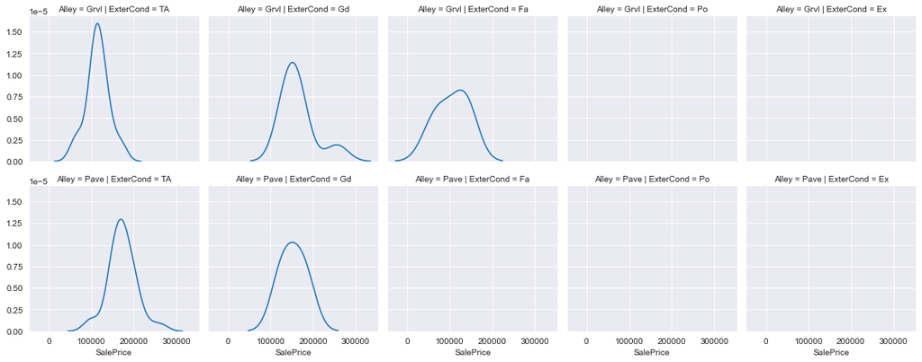

## Q4) Create a simple chart to identify the median Sale price for each year and interpret the results.{SalePrice, YrSold}

```
sns.set_style(style="darkgrid")
sns.barplot(data=df,x='YrSold',y='SalePrice',estimator=np.median);
```

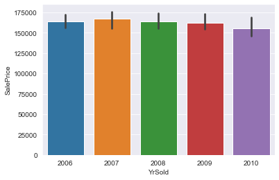

here 2006,2007,2008 and 2009 median sale price is around 160000.but 2010 median sale prices around 150000

## Q5) By creating necessary graphs interpret which of the following 2 variable have high relationship with Sale price. [20 marks >> 5,5,10]

### a) Relationship between price and living area square feet {GrLivArea, SalePrice }

```
g = sns.JointGrid(data=df,y='SalePrice',x='GrLivArea')
g.plot(sns.regplot, sns.distplot);
```

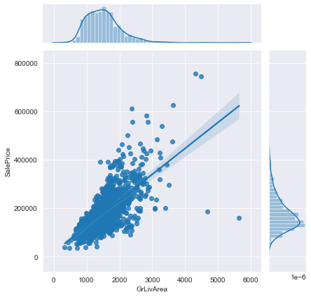

### b) Relationship between price and square feet of basement area {TotalBsmtSF, SalePrice}

```
sns.lmplot(x='TotalBsmtSF',y='SalePrice',data=df);
```

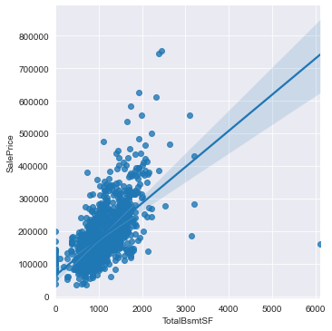

### c) Finally comment a or b have high relationship with sales price by mentioning graphical reasons. (Use regression plot to create both regression line in the same graph to validate your arguments)

```
sns.regplot(data=df,y='SalePrice',x='GrLivArea')
sns.regplot(x='TotalBsmtSF',y='SalePrice',data=df);
```

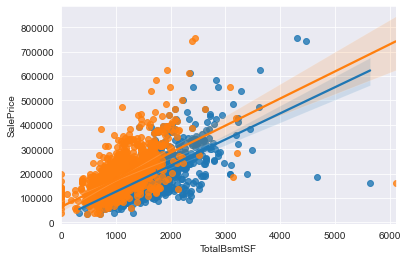

## Q6) In an effort to visualize all the points of Sales price with respect to rating of basement, a student tried run below code to create a chart: {SalePrice, BsmtFinType1} [15 marks >> 5 each]

sns.relplot(data = df, x='SalePrice', y='BsmtFinType1')

### a) Run the above code, create the chart, and explain what is the visual issue in this chart?

```
sns.relplot(data = df, x='SalePrice', y='BsmtFinType1' );
```

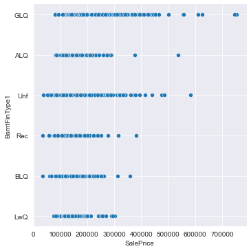

In this graph,we can see what is the minimum and maximum prices for each BsmtFinType1 categories.but we can not find distribution to find median price interval and outliers.

### b) Suggest a modern type of chart in seaborn we can use to visualize the same information but avoiding the issue you mentioned in question 6.a.

```
sns.boxplot(data = df, x='SalePrice', y='BsmtFinType1');
```

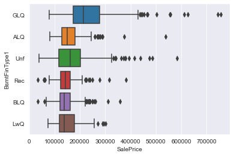

### c) Based on this chart interpret your findings.

In this box plot, we can see median house prices: *Good Living Quarters>Unfinshed>other quarters*.

there are more outliers in this graph.unfinished Quaters lower price is lower than other quarters.

from 110000 to 180000 price range, we can get lotsof houses in each BsmtFinType1 categories except Good Living Quarters.but around 220000 we can get more houses in Good Living Quarters.

## Q7) Using the same variables in 3.c create a boxplot and violin plot in seaborn. Main category Should be Alley type and distinguish exterior condition using color. Interpret and discuss pros and cons of charts in 7 comparing it with chart created in 3.c (50 – 100 words) {SalePrice, Alley, ExterCond} [15 marks]

```
sns.boxplot(data=df,x='ExterCond',y='SalePrice',hue='Alley');
sns.violinplot(data=df,x='ExterCond',y='SalePrice',hue='Alley');
```

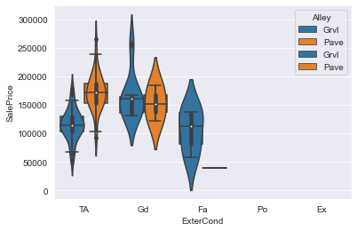

when we see average houses(TA) the meadian of gravel less than meadian of paved. that is mean most of the average houses price around 160000 in paved Street and around 120000 in graval Street.

similarly most of the good houses price around 160000 in graval Street and 150000 in paved Street

most of the fair houses price around 120000 in graval Street

## Q8) Do you think, average sales price is changing with respect to month they sell? Create necessary plot and interpret the results [10 marks] {SalePrice, MoSold}

```
sns.boxplot(data=df,x='MoSold',y='SalePrice');
```

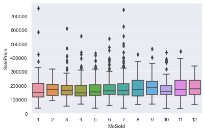

```
sns.barplot(data=df,x='MoSold',y='SalePrice',estimator=np.median)
```

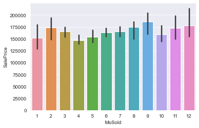

normally we take average as mean value but in this graph we have lot of outlier so that mean is not suitable for this graph so we we should take median as average.

in the September house prices very high than other months.